# Project Foundations for Data Science: FoodHub Data Analysis

**Marks: 40**

### Context

The number of restaurants in New York is increasing day by day. Lots of students and busy professionals rely on those restaurants due to their hectic lifestyles. Online food delivery service is a great option for them. It provides them with good food from their favorite restaurants. A food aggregator company FoodHub offers access to multiple restaurants through a single smartphone app.

The app allows the restaurants to receive a direct online order from a customer. The app assigns a delivery person from the company to pick up the order after it is confirmed by the restaurant. The delivery person then uses the map to reach the restaurant and waits for the food package. Once the food package is handed over to the delivery person, he/she confirms the pick-up in the app and travels to the customer's location to deliver the food. The delivery person confirms the drop-off in the app after delivering the food package to the customer. The customer can rate the order in the app. The food aggregator earns money by collecting a fixed margin of the delivery order from the restaurants.

### Objective

The food aggregator company has stored the data of the different orders made by the registered customers in their online portal. They want to analyze the data to get a fair idea about the demand of different restaurants which will help them in enhancing their customer experience. Suppose you are hired as a Data Scientist in this company and the Data Science team has shared some of the key questions that need to be answered. Perform the data analysis to find answers to these questions that will help the company to improve the business.

### Data Description

The data contains the different data related to a food order. The detailed data dictionary is given below.

### Data Dictionary

- order_id: Unique ID of the order
- customer_id: ID of the customer who ordered the food
- restaurant_name: Name of the restaurant
- cuisine_type: Cuisine ordered by the customer
- cost: Cost of the order
- day_of_the_week: Indicates whether the order is placed on a weekday or weekend (The weekday is from Monday to Friday and the weekend is Saturday and Sunday)
- rating: Rating given by the customer out of 5
- food_preparation_time: Time (in minutes) taken by the restaurant to prepare the food. This is calculated by taking the difference between the timestamps of the restaurant's order confirmation and the delivery person's pick-up confirmation.
- delivery_time: Time (in minutes) taken by the delivery person to deliver the food package. This is calculated by taking the difference between the timestamps of the delivery person's pick-up confirmation and drop-off information

### Importing the required libraries

The following libraries will help with reading-in, manipulating, analysing and visualising the data.

```python
# Importing the library packages
import pandas as pd  # library used for data manipulation and analysis
import numpy as np  # library used for working with arrays
import matplotlib.pyplot as plt  # library for plots and visualizations
import seaborn as sns  # library for visualizations
```

```python
# Setting the display layout format for the plots
%matplotlib inline
```

```python
# Suppressing warnings
import warnings
warnings.filterwarnings('ignore')
```

### Understanding the structure of the data

```python
# Loading the data set
df = pd.read_csv('foodhub_order.csv', sep = ',')
```

```python
# Copying data to another variable to avoid any changes to the original data
fd_hub = df.copy()
```

```python
# Looking at the data-set head using the default view which shows the first 5 observations
df.head()
```

|  | order_id | customer_id | restaurant_name | cuisine_type | cost_of_the_order | day_of_the_week | rating | food_preparation_time | delivery_time |
| --- | --- | --- | --- | --- | --- | --- | --- | --- | --- |
| 0 | 1477147 | 337525 | Hangawi | Korean | 30.75 | Weekend | Not given | 25 | 20 |
| 1 | 1477685 | 358141 | Blue Ribbon Sushi Izakaya | Japanese | 12.08 | Weekend | Not given | 25 | 23 |
| 2 | 1477070 | 66393 | Cafe Habana | Mexican | 12.23 | Weekday | 5 | 23 | 28 |
| 3 | 1477334 | 106968 | Blue Ribbon Fried Chicken | American | 29.20 | Weekend | 3 | 25 | 15 |
| 4 | 1478249 | 76942 | Dirty Bird to Go | American | 11.59 | Weekday | 4 | 25 | 24 |

```python
# Looking at the tail
df.tail()
```

|  | order_id | customer_id | restaurant_name | cuisine_type | cost_of_the_order | day_of_the_week | rating | food_preparation_time | delivery_time |
| --- | --- | --- | --- | --- | --- | --- | --- | --- | --- |
| 1893 | 1476701 | 292602 | Chipotle Mexican Grill $1.99 Delivery | Mexican | 22.31 | Weekend | 5 | 31 | 17 |
| 1894 | 1477421 | 397537 | The Smile | American | 12.18 | Weekend | 5 | 31 | 19 |
| 1895 | 1477819 | 35309 | Blue Ribbon Sushi | Japanese | 25.22 | Weekday | Not given | 31 | 24 |
| 1896 | 1477513 | 64151 | Jack's Wife Freda | Mediterranean | 12.18 | Weekday | 5 | 23 | 31 |
| 1897 | 1478056 | 120353 | Blue Ribbon Sushi | Japanese | 19.45 | Weekend | Not given | 28 | 24 |

#### Observations:

The data in each row corresponds to the order placed by a customer. Each order observed has a distinct identification number 'order_id'. The customer who placed the order is identified by the customer_id column and the restaurant receiving and preparing the order by its name. The cuisine type is categorised by country of origin whilst, the day of the week of the order is categorised by 'Weekend' or 'Weekday'. The cost, duration for preparation and delivery time of each observed order are given in their respective columns. Lastly, the ratings column consists of numeric observations i.e., scores given by customers for an order. Where scores were not given, the string "Not given" appears.

### **Question 1:** How many rows and columns are present in the data?

```python
# Checking the shape of the data-set
df.shape
```

```
(1898, 9)
```

#### Observations:

The data frame has **1,898 rows** and **9 columns**

### **Question 2:** What are the datatypes of the different columns in the dataset? (The info() function can be used)

```python
# Checking the metadata of the data-set colums using .info()
df.info();
```

```
<class 'pandas.core.frame.DataFrame'>
RangeIndex: 1898 entries, 0 to 1897
Data columns (total 9 columns):
 #   Column                 Non-Null Count  Dtype
---  ------                 --------------  -----
 0   order_id               1898 non-null   int64
 1   customer_id            1898 non-null   int64
 2   restaurant_name        1898 non-null   object
 3   cuisine_type           1898 non-null   object
 4   cost_of_the_order      1898 non-null   float64
 5   day_of_the_week        1898 non-null   object
 6   rating                 1898 non-null   object
 7   food_preparation_time  1898 non-null   int64
 8   delivery_time          1898 non-null   int64
dtypes: float64(1), int64(4), object(4)
memory usage: 133.6+ KB
```

#### Observations:

- The columns all have 1,898 observations, each.
- The columns with observations of numeric subclass and integer type are order_id, customer_id, food_preparation_time and delivery_time. The column, cost_of_the_order, is of float type.
- The columns with observations of non-numeric subclass and obect type are restaurant_name, cuisine_type, day_of_the_week and rating.
- The data types for all the columns appear to be appropriate for the purposes of further analysis except for the rating column.

### **Question 3:** Are there any missing values in the data? If yes, treat them using an appropriate method

```python
# Checking if there are missing values
df.isna().sum()
```

```
order_id                 0
customer_id              0
restaurant_name          0
cuisine_type             0
cost_of_the_order        0
day_of_the_week          0
rating                   0
food_preparation_time    0
delivery_time            0
dtype: int64
```

### **Question 4:** Check the statistical summary of the data. What is the minimum, average, and maximum time it takes for food to be prepared once an order is placed?

```python
# Using .describe() to view the statistical summary of the columns with numerical values.
df.describe().T
```

|  | count | mean | std | min | 25% | 50% | 75% | max |
| --- | --- | --- | --- | --- | --- | --- | --- | --- |
| order_id | 1898.0 | 1.477496e+06 | 548.049724 | 1476547.00 | 1477021.25 | 1477495.50 | 1.477970e+06 | 1478444.00 |
| customer_id | 1898.0 | 1.711685e+05 | 113698.139743 | 1311.00 | 77787.75 | 128600.00 | 2.705250e+05 | 405334.00 |
| cost_of_the_order | 1898.0 | 1.649885e+01 | 7.483812 | 4.47 | 12.08 | 14.14 | 2.229750e+01 | 35.41 |
| food_preparation_time | 1898.0 | 2.737197e+01 | 4.632481 | 20.00 | 23.00 | 27.00 | 3.100000e+01 | 35.00 |
| delivery_time | 1898.0 | 2.416175e+01 | 4.972637 | 15.00 | 20.00 | 25.00 | 2.800000e+01 | 33.00 |

#### Observations:

The statistical summary shows that once an order is placed;

- The minimum order preparation time is 20 minutes
- The average order preparation time is 27 minutes
- The maximum order preparation time is 35 minutes

### **Question 5:** How many orders are not rated?

```python
df.rating.value_counts()
```

```
rating
Not given    736
5            588
4            386
3            188
Name: count, dtype: int64
```

#### Observations:

The sum of orders not rated is 736. They are made up the observations "Not given" and indicate that there is a problem of non-responses in the app when users are required to score their satisfaction with their orders. To enable proper analysis of the data, the "Not given" observations must be dropped or treated as a separate category. Furthermore, the column data type for 'rating' must be set to a numeric sub-class.

#### Observations:

After checking the statistical summary, it is also useful to check the summary of categorical variables.

```python
# Checking the summary of categorical variables
df.describe(exclude = 'number').T
```

|  | count | unique | top | freq |
| --- | --- | --- | --- | --- |
| restaurant_name | 1898 | 178 | Shake Shack | 219 |
| cuisine_type | 1898 | 14 | American | 584 |
| day_of_the_week | 1898 | 2 | Weekend | 1351 |
| rating | 1898 | 4 | Not given | 736 |

### Exploratory Data Analysis (EDA)

### Univariate Analysis

#### **Question 6:** Explore all the variables and provide observations on their distributions. (Generally, histograms, boxplots, countplots, etc. are used for univariate exploration)

In order to perform a satisfactory exploratory analysis on the variables in the data frame, I would like to first look at the numerical variables and categorical variables separately.

##### **Question 6a)

Exploring the numerical variables - Preparing the data

Since the rating column has numerical values that are important to determine customer satisfaction levels, I will group the variable with the numerical variables. To do this, I will exclude the observations of orders without ratings, change the data type for the column and reset the index of the modified data frame.

```python
# Storing the dataframe without the missing ratings
df_rated = df[df["rating"].str.contains("Not given") == False]

# Changing the data type of the rating column to type int
df_rated.rating = df_rated.rating.astype(int)

# Resetting the index for the data frame
df_rated.reset_index(drop=True)

# Checking that the data type has changed to type int
df_rated.rating.dtype
```

```
dtype('int32')
```

```python
# Checking the snippet of the modified datafrome
df_rated.head(3)
```

|  | order_id | customer_id | restaurant_name | cuisine_type | cost_of_the_order | day_of_the_week | rating | food_preparation_time | delivery_time |
| --- | --- | --- | --- | --- | --- | --- | --- | --- | --- |
| 2 | 1477070 | 66393 | Cafe Habana | Mexican | 12.23 | Weekday | 5 | 23 | 28 |
| 3 | 1477334 | 106968 | Blue Ribbon Fried Chicken | American | 29.20 | Weekend | 3 | 25 | 15 |
| 4 | 1478249 | 76942 | Dirty Bird to Go | American | 11.59 | Weekday | 4 | 25 | 24 |

```python
df_rated.shape
```

```
(1162, 9)
```

The modified dataframe is ready for further analysis, it has **1,162 rows and 9 columns**.

```python
# Defining the numerical variables as a group and storing them as variable; num_vars
num_vars = pd.DataFrame (df_rated,
                        columns =
                         ['cost_of_the_order',
                          'rating',
                        'food_preparation_time',
                        'delivery_time'])
```

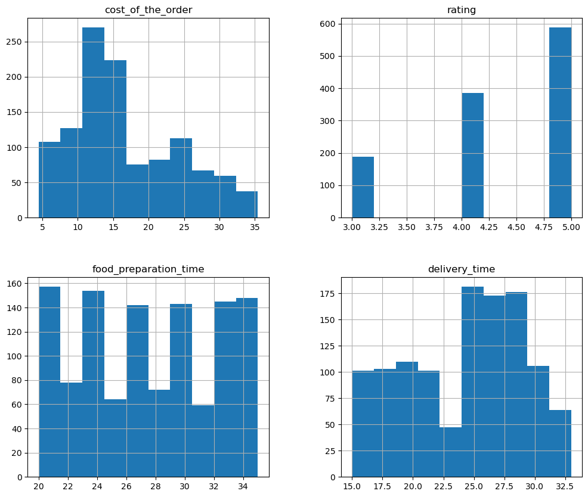

```python
# Plotting all the numerical variables on one grid
import matplotlib.pyplot as plt
%matplotlib inline

num_vars.hist(figsize=(12, 10));
```

#### Observations:

The histograms show the distribution of the variables at a glance. For a closer look at each variable, I will plot them separately using seaborn's boxplot and histogram functions.

```python
# Loading the libraries required to make the plots
import seaborn as sns
import numpy as np
import matplotlib.pyplot as plt

# Defining the plotting function
def histogram_boxplot(feature, figsize=(15, 10), bins="auto"):
    """ Boxplot and histogram combined
    feature: 1-d feature array
    figsize: size of fig (default (15, 10))
    bins: number of bins (default "auto")
    """
    f, (ax_box, ax_hist) = plt.subplots(
        nrows=2,  # Number of rows of the subplot grid
        sharex=True,  # The X-axis will be shared among all the subplots
        gridspec_kw={"height_ratios": (.25, .75)},
        figsize=figsize
    )

    # Creating the subplots
    # Boxplot will be created and the mean value of the column will be indicated using some symbol
    sns.boxplot(x=feature, ax=ax_box, showmeans=True, color='red')

    # For histogram
    sns.histplot(x=feature, kde=False, ax=ax_hist, bins=bins)
    ax_hist.axvline(np.mean(feature), color='g', linestyle='--')      # Adding mean to the histogram
    ax_hist.axvline(np.median(feature), color='black', linestyle='-') # Adding median to the histogram

    plt.show()
```

**Question 6 a)i. Univariate analysis of the price of an order

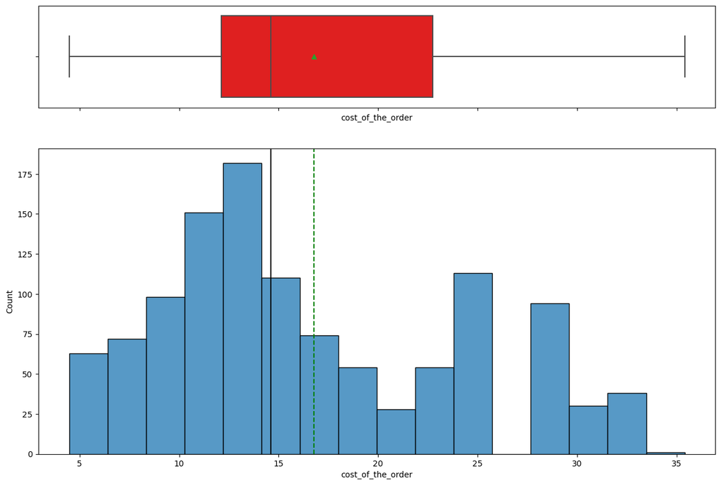

```python
# Running the function on the variable; cost of the order
histogram_boxplot(num_vars.cost_of_the_order);
```

**Observations**

- The distribution of the cost of orders is slightly right-skewed.
- The median cost is between 14 and 15, with the mean being ~17.
- No outliers are observed in the variable.

**Question 6 a)ii. Univariate analysis of the ratings

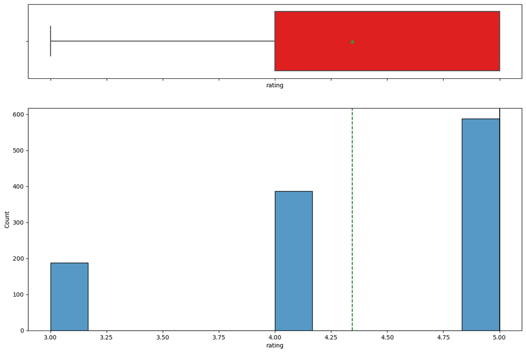

```python
# Running the function on the variable; rating
histogram_boxplot(num_vars.rating);
```

**Observations**

- The distribution of the ratings is highly left-skewed.
- The median rating is 5, with mean ~4.30.
- No outliers are observed in the variable.

**Question 6 a)iii. Univariate analysis of the order preparation time

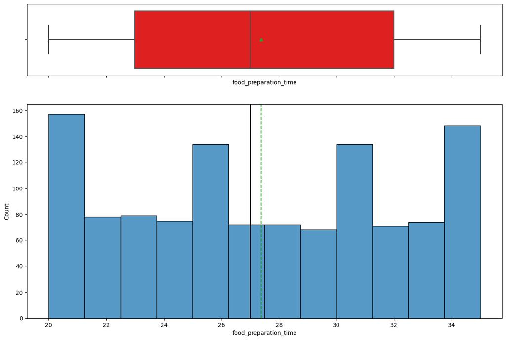

```python
# Running the function on the variable; food preparation time
histogram_boxplot(num_vars.food_preparation_time)
```

**Observations**

**Question 6 a)iv. Univariate analysis of the order delivery time

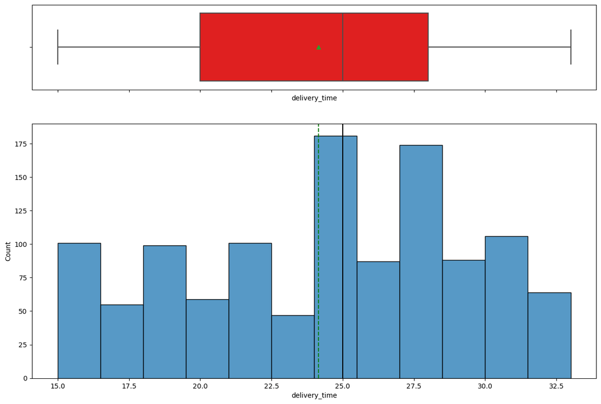

```python
# Running the function on the variable; food delivery time
histogram_boxplot(num_vars.delivery_time)
```

**Observations**

- The distribution of the variable delivery time is also highly centred around the mean.
- The median delivery time is 25, with mean ~24.00.
- No outliers are observed in the variable.

##### **Question 6b)

Exploring the categorical variables - Preparing the data

```python
# Defining the categorical variables as a group and storing them as variable; cat_vars
cat_vars = pd.DataFrame (df_rated,
                        columns =
                         ['restaurant_name',
                        'cuisine_type',
                        'day_of_the_week'])
```

I will explore the categorical variables using barplots where it is appropriate.

```python
# Defining the plotting function
def bar_perc(data, z):
    total = len(data[z]) # Length of the column
    plt.figure(figsize = (15, 5))

    # Convert the column to a categorical data type
    data[z] = data[z].astype('category')

    ax = sns.countplot(x=z, data=data, palette='Paired', order=data[z].value_counts().index)

    for p in ax.patches:
        percentage = '{:.1f}%'.format(100 * p.get_height() / total) # Percentage of each class
        x = p.get_x() + p.get_width() / 2 - 0.05                    # Width of the plot
        y = p.get_y() + p.get_height()                              # Height of the plot
        ax.annotate(percentage, (x, y), size = 12)                  # Annotate the percentage

    plt.show()                                                      # Display the plot
```

**Question 6 b)i. Univariate analysis of the restaurants by name

Owing to the large number of restaurants in the data frame, it is difficult to visualise the frequency of observations for all the values by running e.g., * bar_perc(cat_vars, 'restaurant_name'* . It is instructive however to view the most and least frequently appearing restaurants to gain some insight into the variable.

```python
# Making the list of all categorical variables
cat_col = ['restaurant_name']

# Printing the frequency count of each unique value per coloumn
for column in cat_col:
    print(df_rated[column].value_counts())

    print('-' * 50)
```

```
restaurant_name
Shake Shack                    133
The Meatball Shop               84
Blue Ribbon Sushi               73
Blue Ribbon Fried Chicken       64
RedFarm Broadway                41
                              ...
Philippe Chow                    1
Dirty Bird To Go (archived)      1
The MasalaWala                   1
Kambi Ramen House                1
'wichcraft                       1
Name: count, Length: 156, dtype: int64
--------------------------------------------------
```

**Observations**

- The top five restaurants received orders in the range 41 - 133
- The bottom five restaurants each received single orders

Question 6 b)ii. Univariate analysis of the variable, cuisine type

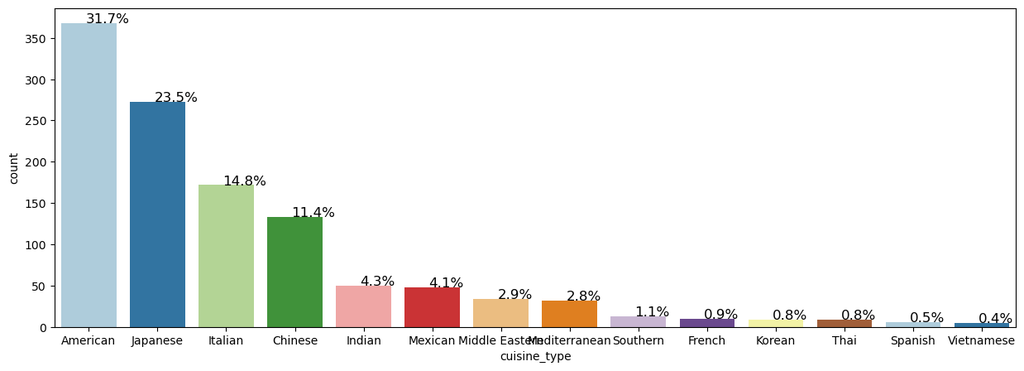

```python
bar_perc(cat_vars, 'cuisine_type');
```

**Observations**

Question 6 b)iii. Univariate analysis of the variable, day of the week

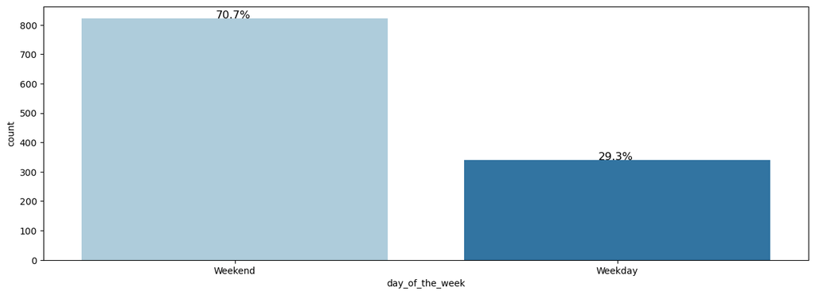

```python
bar_perc(cat_vars, 'day_of_the_week')
```

**Observations**

- 70.7% of the orders were placed during weekends

### **Question 7**: Which are the top 5 restaurants in terms of the number of orders received?

```python
# Making the list of all categorical variables
cat_col = ['restaurant_name']

# Printing the frequency count of each unique value per coloumn
for column in cat_col:
    print(df[column].value_counts())

    print('-' * 50)
```

```
restaurant_name
Shake Shack                  219
The Meatball Shop            132
Blue Ribbon Sushi            119
Blue Ribbon Fried Chicken     96
Parm                          68
                            ...
Sushi Choshi                   1
Dos Caminos Soho               1
La Follia                      1
Philippe Chow                  1
'wichcraft                     1
Name: count, Length: 178, dtype: int64
--------------------------------------------------
```

#### Observations:

The top five restaurants by number of orders received are:

### **Question 8**: Which is the most popular cuisine on weekends?

```python
# Using the crosstab function to summarise the cuisine type orders by the day of week
pd.crosstab(index = df.cuisine_type,
            columns = df.day_of_the_week,
            values = df.cost_of_the_order, aggfunc = 'count', margins = True)
```

| day_of_the_week cuisine_type | Weekday | Weekend | All |
| --- | --- | --- | --- |
| American | 169 | 415 | 584 |
| Chinese | 52 | 163 | 215 |
| French | 5 | 13 | 18 |
| Indian | 24 | 49 | 73 |
| Italian | 91 | 207 | 298 |
| Japanese | 135 | 335 | 470 |
| Korean | 2 | 11 | 13 |
| Mediterranean | 14 | 32 | 46 |
| Mexican | 24 | 53 | 77 |
| Middle Eastern | 17 | 32 | 49 |
| Southern | 6 | 11 | 17 |
| Spanish | 1 | 11 | 12 |
| Thai | 4 | 15 | 19 |
| Vietnamese | 3 | 4 | 7 |
| All | 547 | 1351 | 1898 |

#### Observations:

The most popular type of cuisine ordered on the weekend is American cuisine with 415 orders being placed on the app.

### **Question 9**: What percentage of the orders cost more than 20 dollars?

```python
# Calculating the percentage of orders by cost
total_orders = len(df)
high_value_orders = len(df[df['cost_of_the_order'] > 20])
percentage_high_value_orders = (high_value_orders / total_orders) * 100

# Printing the result
print(f"{percentage_high_value_orders:.2f}%")
```

```
29.24%
```

#### Observations:

The observation is that 29% of the orders cost above 20 dollars

### **Question 10**: What is the mean order delivery time?

```python
# Calculating the mean for order delivery time
df['delivery_time'].mean()
```

```
24.161749209694417
```

#### Observations:

The mean order delivery time is 24 minutes.

### **Question 11:** The company has decided to give 20% discount vouchers to the top 3 most frequent customers. Find the IDs of these customers and the number of orders they placed.

```python
# Finding the total number of customer IDs
customers = df['customer_id'].value_counts()

# Checking the total number of customer IDs
unique_ID = df['customer_id'].nunique()
unique_ID
```

```
1200
```

```python
# Filtering the top 3 customer IDs
top_3 = print(customers[:3])
```

```
customer_id
52832    13
47440    10
83287     9
Name: count, dtype: int64
```

#### Observations:

There are 1200 customer unique customer IDs which indicates 1200 unique customers/app users. Customer ID 52832 has a total of 13 orders followed by customer ID 47440 with 10 orders. In the third position, customer ID 83287 has ordered 9 times.

### **Question 12**: Perform a multivariate analysis to explore relationships between the important variables in the dataset. (It is a good idea to explore relations between numerical variables as well as relations between numerical and categorical variables)

**Question 6c) Multivariate analysis of the numerical variables A correlation plot allows us to visualise how the numerical variables relate to each other.

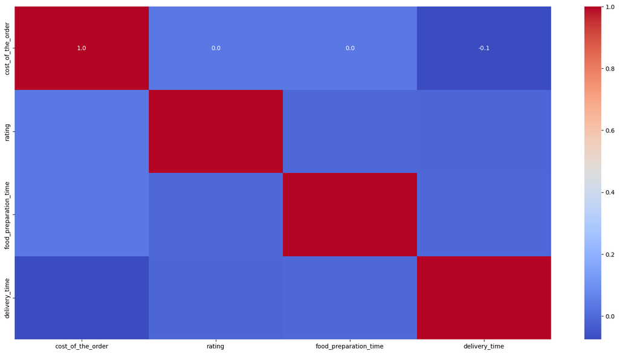

```python
# Checking for correlation among the numerical variables
corr = num_vars.corr()

# Plot the heatmap
plt.figure(figsize = (20, 10))
sns.heatmap(corr, annot = True, cmap = 'coolwarm',
        fmt = ".1f", xticklabels = corr.columns, yticklabels = corr.columns);
```

**Observations**

- The plot shows that there is generally no correlation between the numerical variables of interest.

```python
# Drawing the correlation table for the numerical variables to verify plot results
num_vars.corr()
```

|  | cost_of_the_order | rating | food_preparation_time | delivery_time |
| --- | --- | --- | --- | --- |
| cost_of_the_order | 1.000000 | 0.033983 | 0.035445 | -0.075892 |
| rating | 0.033983 | 1.000000 | -0.006083 | -0.009804 |
| food_preparation_time | 0.035445 | -0.006083 | 1.000000 | -0.008635 |
| delivery_time | -0.075892 | -0.009804 | -0.008635 | 1.000000 |

**Observations**

- The table above provides a tabular view of the correlation of the numerical variables.

It supports the plot by showing the very low correlation values between the variables.

**Question 12a) Multivariate analysis: exploring the relationship between the cuisine type and ratings

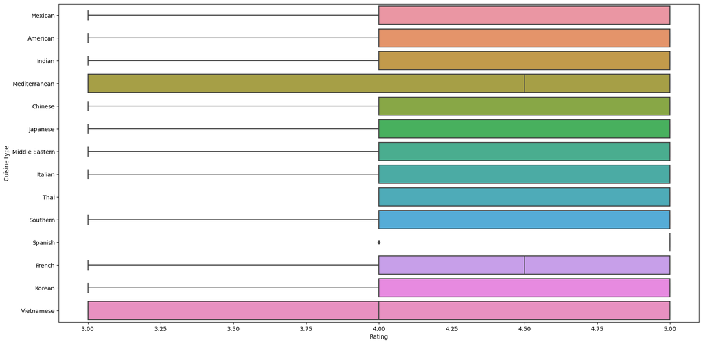

```python
plt.figure(figsize = (20, 10))
sns.boxplot(x='rating', y='cuisine_type',
            data=df_rated).set(xlabel = 'Rating', ylabel = 'Cuisine type');
```

**Observations**

- The majority of the cuisine types were rated between 4 and 5.
- Mediterranean and Vietnamese received ratings between 3 and 5.

**Question 12b)**

[figure not shown]

```python
plt.figure(figsize = (20, 10))
sns.boxplot(x='cost_of_the_order', y='cuisine_type',
            data=df_rated).set(xlabel = 'Cuisine type', ylabel = 'Cost of order');
```

**Observations**

- The distribuition of the cost of orders by cuisine type were mainly similar ranging between **$13 to $25**
- There were outliers in some cuisine types e.g., Korean and Mediterranean

**Question 12c)**

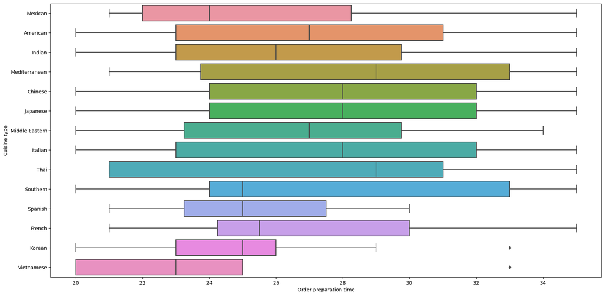

```python
plt.figure(figsize = (20, 10))
sns.boxplot(x='food_preparation_time', y='cuisine_type',
            data=df_rated).set(xlabel = 'Order preparation time', ylabel = 'Cuisine type');
```

**Observations**

- The distribuition of preparation time for orders was more varied, mainly ranging between **23 to 33 minutes**
- There were outliers in some cuisine types e.g., Vietnamese

**Question 12d)**

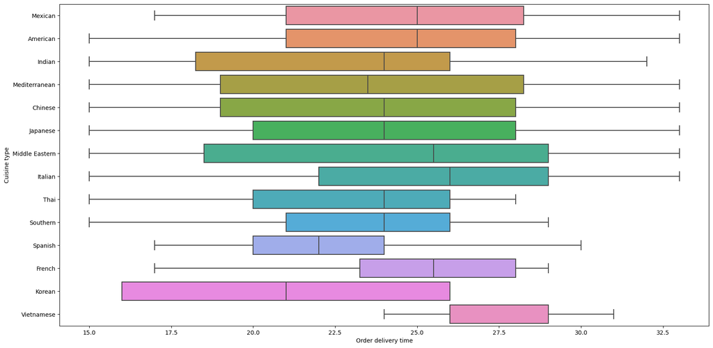

```python
plt.figure(figsize = (20, 10))
pd.crosstab(df_rated['cuisine_type'],df_rated['delivery_time'])
sns.boxplot(x='delivery_time', y='cuisine_type',
            data=df_rated).set(xlabel = 'Order delivery time', ylabel = 'Cuisine type');
```

**Observations**

- The distribuition of delivery time for orders was varied, mainly ranging between **20 to 29 minutes**

**Question 12e)**

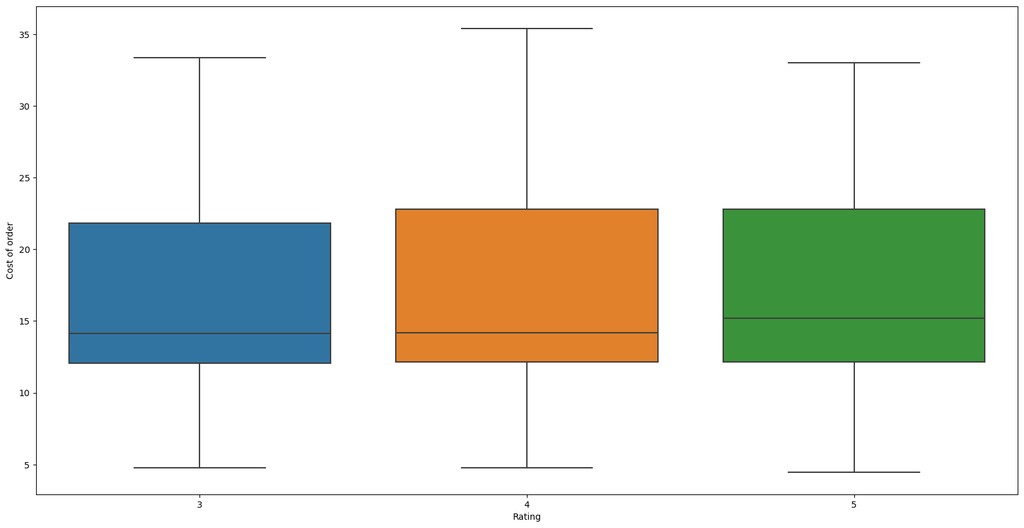

```python
plt.figure(figsize = (20, 10))
sns.boxplot(x='rating',
            y='cost_of_the_order',
            data=df_rated).set(xlabel = 'Rating', ylabel = 'Cost of order');
```

**Observations**

- The distribuition of ratings and the cost of orders was relatively equally distributed *

### **Question 13:** The company wants to provide a promotional offer in the advertisement of the restaurants. The condition to get the offer is that the restaurants must have a rating count of more than 50 and the average rating should be greater than 4. Find the restaurants fulfilling the criteria to get the promotional offer

```python
# Grouping restaurant names by their rating counts and storing them as a dataframe
df_rating_count = df_rated.groupby(
    ['restaurant_name']) ['rating'].count().sort_values(ascending=False).reset_index()

# Filtering the restaurants with rating count more than 50
rest_names = df_rating_count[df_rating_count['rating'] > 50] ['restaurant_name']

# Filtering the restaurants with average rating larger than 4
df_mean_4 = df_rated[df_rated['restaurant_name'].isin(rest_names)].copy()

# Grouping the restaurant names with their ratings and finding the mean rating of each restaurant
promo_qualifiers = df_mean_4.groupby(['restaurant_name'])['rating'].mean().sort_values(ascending=False).reset_index()

#Printing the names of the restaurants
promo_qualifiers
```

|  | restaurant_name | rating |
| --- | --- | --- |
| 0 | The Meatball Shop | 4.511905 |
| 1 | Blue Ribbon Fried Chicken | 4.328125 |
| 2 | Shake Shack | 4.278195 |
| 3 | Blue Ribbon Sushi | 4.219178 |